# Aurélien Nicosia

Aurélien Nicosia, PhD in statistics and lecturer at Université Laval: statistical methodology, R software and teaching resources.

UNIVERSITÉ LAVAL · QUÉBEC

# Aurélien Nicosia

Statistics, data science and university teaching.

Teaching at Université Laval.  
Statistical methodology, R software and open resources.

Explore my work View my background

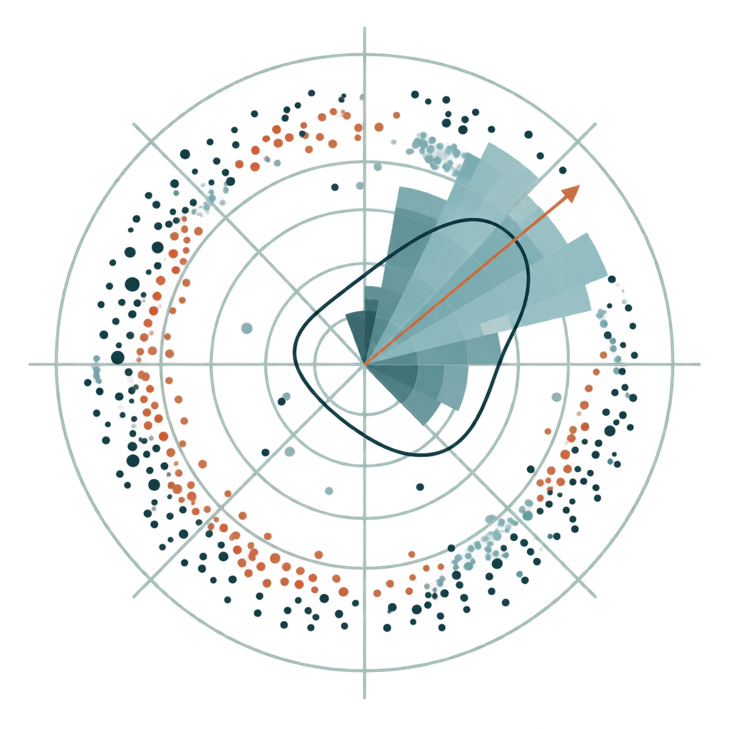

Circular data Density estimation Sequential models ggcircular  
Visualizing circular data Illustrative composition

## A selection of my work

All projects

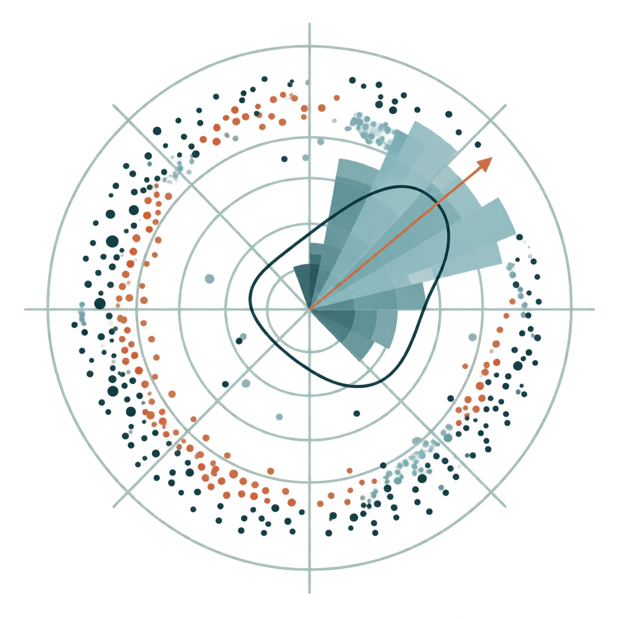

Illustration

### ggcircular

Visualizing circular data

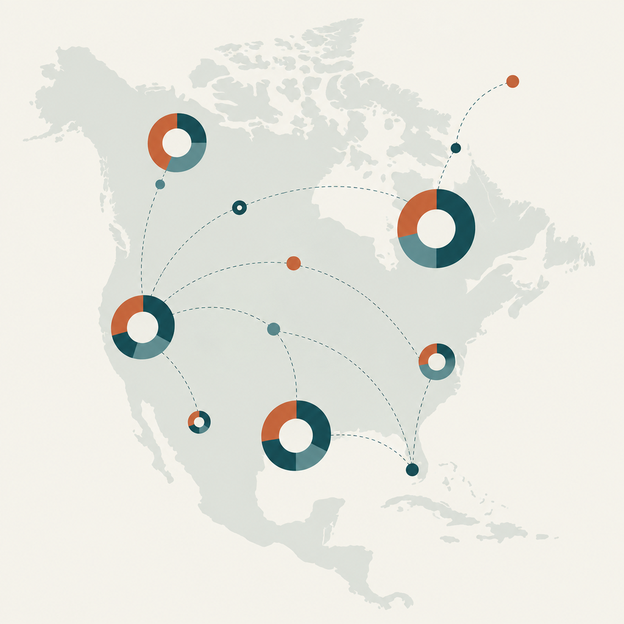

Illustration

### DonutMap

Mapping local compositions

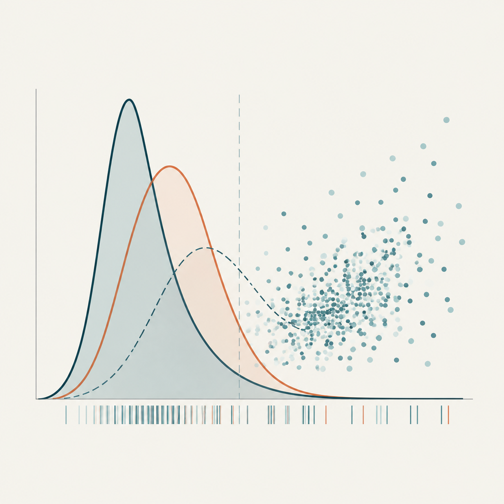

Illustration

### Teaching

Learning statistics and R

## Teaching and student support

Courses, supervision and teaching innovation at Université Laval.

Courses and supervision Teaching innovation CDA and GPT-CDA

## Explore and reuse

Datasets, teaching materials and a library to explore.

Library Open resources

## Computational statistics, diagnostics and uncertainty

I hold a PhD in Statistics and a permanent teaching appointment at Université Laval. I develop methods for understanding latent states, directional data and atypical observations, connecting statistical methodology, R software and university teaching.

## Research, teaching and software

### A connected research program

Three themes: sequential model diagnostics, directional statistics and influence in density estimation. Methods are accompanied by simulation studies and reproducible materials.

Contributions and directions

### Teaching and student training

Undergraduate and graduate teaching in French and English, student project advising and coordination of academic support through the CDA.

Courses and supervision

### Open software and resources

R packages on CRAN, software under development and teaching resources that make methods accessible and analyses verifiable.

Software and documentation

## Updates and highlights

Publication · October 26, 2026

### Inferring behavioural states from animal movement

Our article *Behavioural state inference from movement and environmental data using Markovian step selection functions*, with Ilhem Bouderbala and Daniel Fortin, is published in *PLOS ONE*, 21(10), e0360547. It presents a workflow guided by biological hypotheses for inferring behavioural states, illustrated with a plains zebra trajectory.

[Read the article](https://doi.org/10.1371/journal.pone.0360547)

Publication · October 14, 2026

### Extra hidden states in HMMs

My article *Extra hidden states under emission misspecification in hidden Markov models* is published in *Statistica Neerlandica*, 80(4), e70042. It studies how additional states can compensate for restrictive emission distributions, with a genomic application.

[Read the article](https://doi.org/10.1111/stan.70042) [Code and analyses](https://github.com/AurelienNicosiaULaval/corrective-hmm-states)

Publication · October 6, 2026

### Influenza vaccines: systematic review

Our systematic review and meta-analysis of the relative effectiveness of adjuvanted influenza vaccines for preventing hospitalization is published in *Vaccines*, 14(10), 883, with Daniela Amicizia and our collaborators.

[Read the article](https://doi.org/10.3390/vaccines14100883)

Publication · October 1, 2026

### Visualizing directional dependence

My article *Visualizing directional dependence on cylinders and tori* is published in the *Journal of Data Science, Statistics, and Visualisation*, 6(7). It presents a conditional graphical grammar for data on cylinders and tori, implemented in ggcircular.

[Read the article](https://doi.org/10.52933/jdssv.v6i7.181) ggcircular

Publications

### Animal movement

Two articles published in *Methods in Ecology and Evolution* and *PLOS ONE* address generative validation of step-selection functions and behavioural-state inference. A bioRxiv preprint studies sequential predictive diagnostics for hidden Markov models of animal movement.

[MEE article](https://doi.org/10.1111/2041-210X.70313) [HMM preprint](https://doi.org/10.64898/2026.07.07.737005) [PLOS ONE article](https://doi.org/10.1371/journal.pone.0360547)

Presentations

### SSC 2026

I led a workshop on AI and teaching, contributed to a public teaching-resource gallery, presented work on LOO-LBFP, and received the 2026 New Investigator Presentation Award.

[AI Gallery](https://aureliennicosiaulaval.github.io/ssc-2026-ai-teaching-gallery/) [LOO-LBFP presentation](https://github.com/AurelienNicosiaULaval/ssc-2026-loo-lbfp-presentation/raw/main/main-beamer.pdf)

Open teaching resources

### Données bleues

Quebec and Canadian datasets for teaching statistics and R, with activities, source documentation and reusable teaching materials.

[Explore the resources](https://aureliennicosiaulaval.github.io/donnees-bleues/)

R software

### leaflet.indoor and lmmix

Two software projects available on GitHub: multi-level indoor maps and Gaussian mixed models with correlated residuals. Their development status is stated on each project page.

leaflet.indoor lmmix

Teaching

### Fall 2026 courses

Updated course sites for STT-1100, STT-4230 / STT-6230 and MQT-2101 bring together notes, activities and resources for reproducible data analysis.

Teaching

Seminar

### Au-delà du prompt

Slides and a PDF from the September 18, 2026 OSD seminar on designing a teaching ecosystem with AI. Materials are in French.

Seminar resources

Student support

### GPT-CDA in ULaval News

On May 22, 2026, ULaval News published a story about GPT-CDA, a conversational assistant designed to support learning in mathematics and statistics at the CDA.

[Read the article](https://nouvelles.ulaval.ca/2026/05/22/le-gpt-cda-un-robot-conversationnel-qui-epaule-les-etudiantes-et-etudiants-dans-les-cours-de-mathematiques-et-de-statistique-66c35c61-4649-41a0-befb-c2f79036ac30) CDA page

R software

### Recent packages on CRAN

`GLBFP`, `DonutMap`, `ggcircular`, `CircularRegression`, and `tutorizeR` support density estimation, statistical mapping, circular-data visualization, circular regression, and interactive tutorial creation.

DonutMap ggcircular CircularRegression tutorizeR

Read the academic CV: experience, publications, software, teaching, supervision, funding and service. PDF versions in French and English.